# Zombies Apocalypse

- Data Source: [Kaggle](https://www.kaggle.com/datasets/kingabzpro/zombies-apocalypse)
- Tasks: compare humans and zombies to identify differences in supplies
- Language: [R](https://www.r-project.org/)

## Context

News reports suggest that the impossible has become possible…zombies have appeared on the streets of the US! What should we do? The Centers for Disease Control and Prevention (CDC) zombie preparedness website recommends storing water, food, medication, tools, sanitation items, clothing, essential documents, and first aid supplies. Thankfully, we are CDC analysts and are prepared, but it may be too late for others!

## Content

Our team decides to identify supplies that protect people and coordinate supply distribution. A few brave data collectors volunteer to check on 200 randomly selected adults who were alive before the zombies. We have recent data for the 200 on age and sex, how many are in their household, and their rural, suburban, or urban location. Our heroic volunteers visit each home and record zombie status and preparedness. Now it's our job to figure out which supplies are associated with safety!

## File

Because every moment counts when dealing with life and (un)death, we want to get this right! The first task is to compare humans and zombies to identify differences in supplies. We review the data and find the following:

- zombieid: unique identifier
- zombie: human or zombie
- age: age in years
- sex: male or female
- rurality: rural, suburban, or urban
- household: number of people living in household
- water: gallons of clean water available
- food: food or no food
- medication: medication or no medication
- tools: tools or no tools
- firstaid: first aid or no first aid
- sanitation: sanitation or no sanitation
- clothing: clothing or no clothing
- documents: documents or no documents

## Acknowledgements

DataCamp

```r
library(tidyverse)
```

```r
theme_set(theme_light())
```

```r
set.seed(421)
"Sabine Jana Sascha Markus" %>%  str_split(" ") %>% unlist %>% sample %>% str_c(collapse=" → ")
```

'Markus → Sabine → Jana → Sascha'

## 1. Data loading

```r
zombie_data=read_csv("zombies.csv")
```

```r
zombie_data |>tail()
```

A tibble: 6 × 14

| zombieid <dbl> | zombie <chr> | age <dbl> | sex <chr> | rurality <chr> | household <dbl> | water <dbl> | food <chr> | medication <chr> | tools <chr> | firstaid <chr> | sanitation <chr> | clothing <chr> | documents <chr> |
| --- | --- | --- | --- | --- | --- | --- | --- | --- | --- | --- | --- | --- | --- |
| 195 | Zombie | 67 | Female | Suburban | 2 | 0 | No food | No medication | No tools | No first aid supplies | No sanitation | NA | NA |
| 196 | Zombie | 68 | Male | Suburban | 1 | 0 | Food | No medication | No tools | No first aid supplies | Sanitation | Clothing | Documents |
| 197 | Zombie | 71 | Male | Suburban | 1 | 8 | No food | No medication | tools | First aid supplies | No sanitation | Clothing | NA |
| 198 | Zombie | 76 | Female | Urban | 1 | 0 | No food | No medication | tools | First aid supplies | Sanitation | Clothing | Documents |
| 199 | Zombie | 82 | Male | Urban | 1 | 0 | No food | No medication | No tools | No first aid supplies | No sanitation | NA | NA |
| 200 | Zombie | 85 | Male | Urban | 1 | 0 | No food | Medication | No tools | No first aid supplies | Sanitation | Clothing | NA |

```r
zombie_data |>summary()
```

```
    zombieid         zombie               age            sex
 Min.   :  1.00   Length:200         Min.   :18.00   Length:200
 1st Qu.: 50.75   Class :character   1st Qu.:29.00   Class :character
 Median :100.50   Mode  :character   Median :42.00   Mode  :character
 Mean   :100.50                      Mean   :44.41
 3rd Qu.:150.25                      3rd Qu.:58.00
 Max.   :200.00                      Max.   :85.00
   rurality           household        water           food
 Length:200         Min.   :1.00   Min.   : 0.00   Length:200
 Class :character   1st Qu.:2.00   1st Qu.: 0.00   Class :character
 Mode  :character   Median :2.50   Median : 8.00   Mode  :character
                    Mean   :2.68   Mean   : 8.75
                    3rd Qu.:4.00   3rd Qu.: 8.00
                    Max.   :6.00   Max.   :40.00
  medication           tools             firstaid          sanitation
 Length:200         Length:200         Length:200         Length:200
 Class :character   Class :character   Class :character   Class :character
 Mode  :character   Mode  :character   Mode  :character   Mode  :character



   clothing          documents
 Length:200         Length:200
 Class :character   Class :character
 Mode  :character   Mode  :character
```

# split in zombie and non-zombie

- what are the differences in supplies between the two groups?
- which supply is the best indicator for zombieness?

-> count yes/no per group, bar plot

```r
zombie_bar = function(feature){
    feature <- sym(feature)
    zombie_data %>%
        ggplot(aes(x = !!feature, fill  = zombie)) + geom_bar()
}
```

```r
zombie_bar2 = function(feature){
    feature <- sym(feature)
    zombie_data %>%
        ggplot(aes(fill = !!feature, x  = zombie)) + geom_bar()
}
```

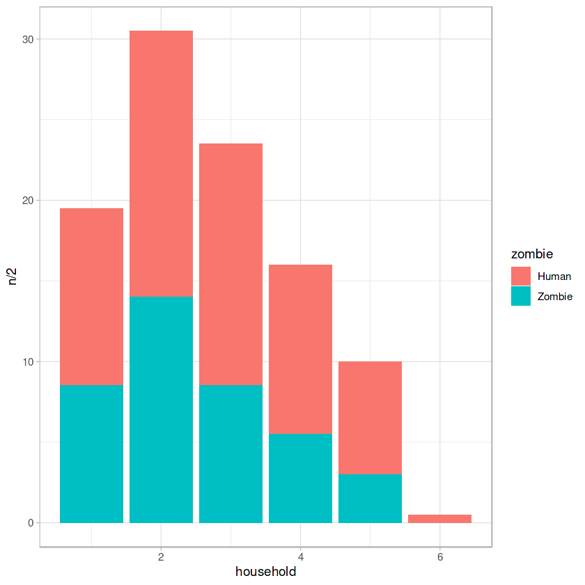

```r
#zombie_col = function(feature){
    zombie_data %>% group_by(zombie) %>% count(household) %>%
    ggplot(aes(x = household, y = n/2,fill = zombie)) + geom_col()
#}
```

```r
#map(colnames(zombie_data),zombie_col)
```

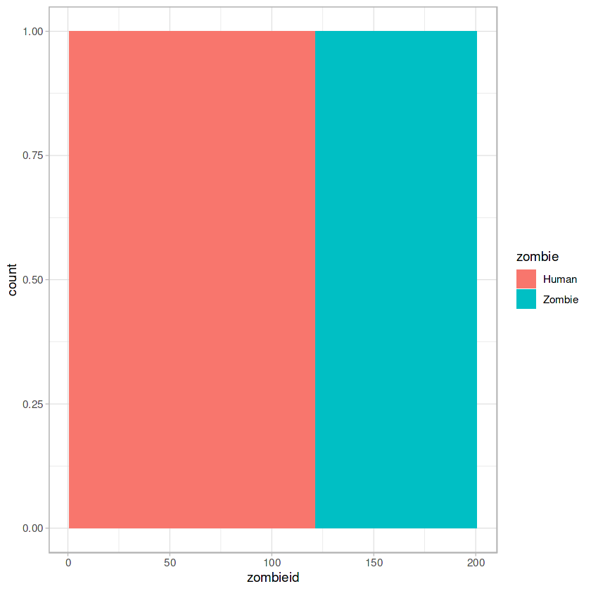

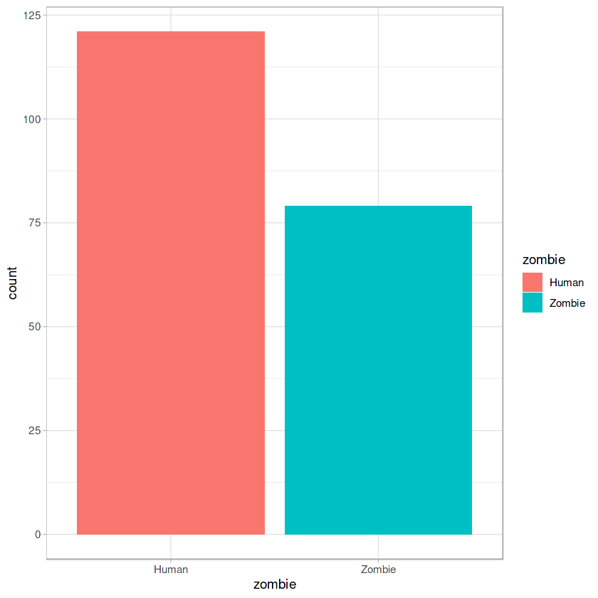

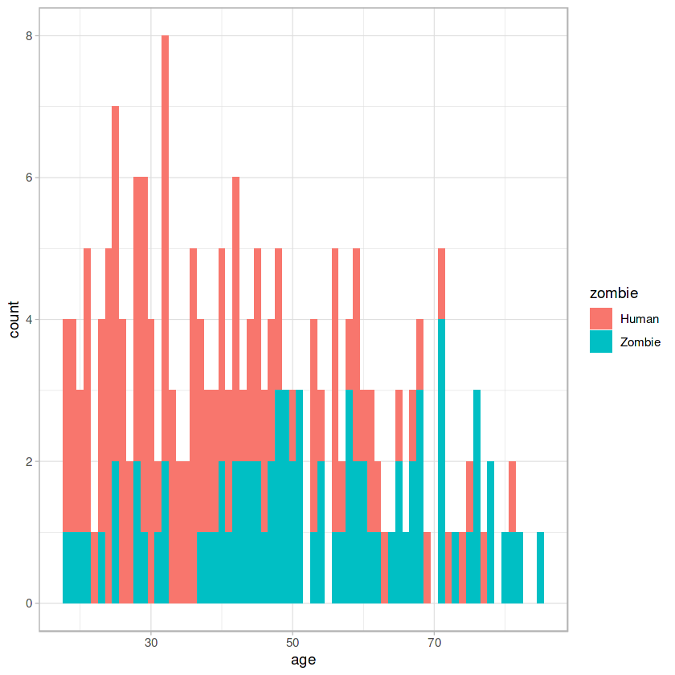

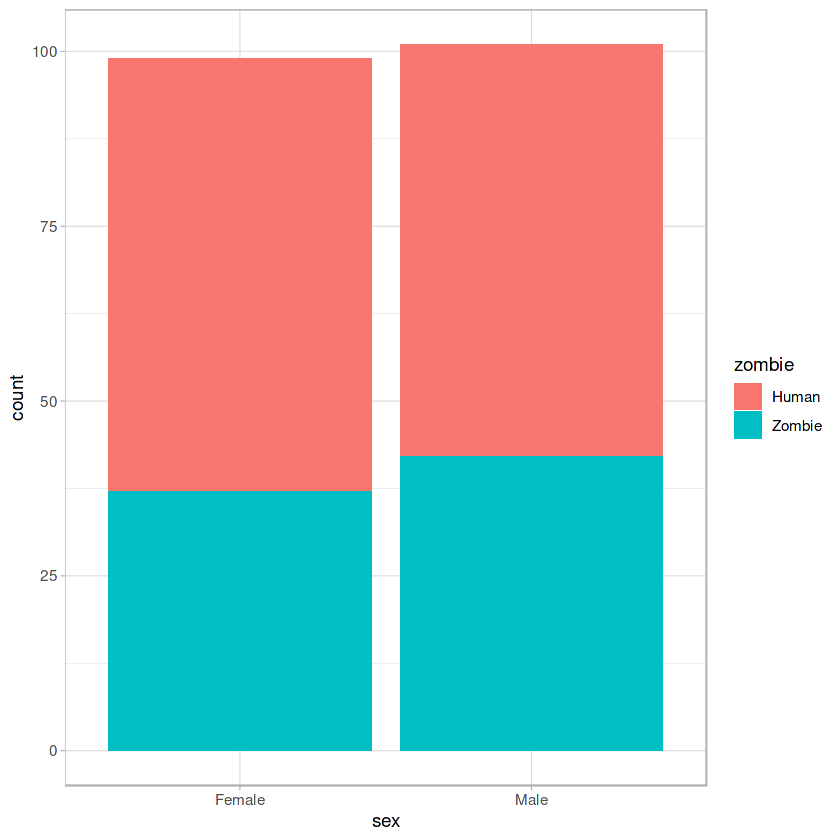

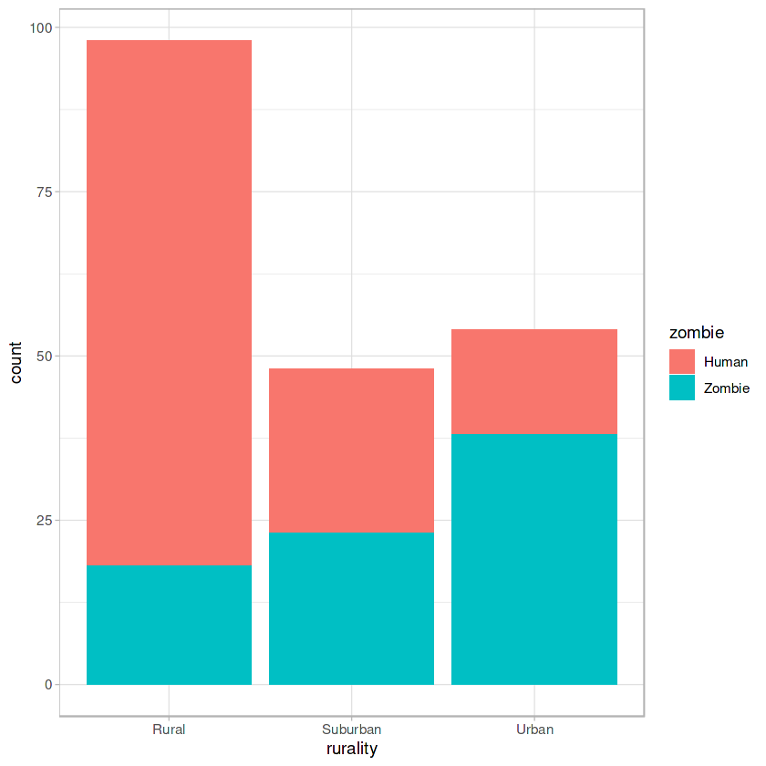

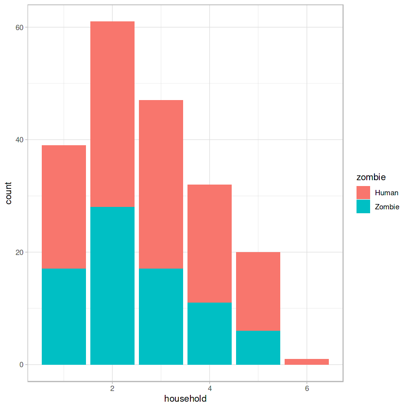

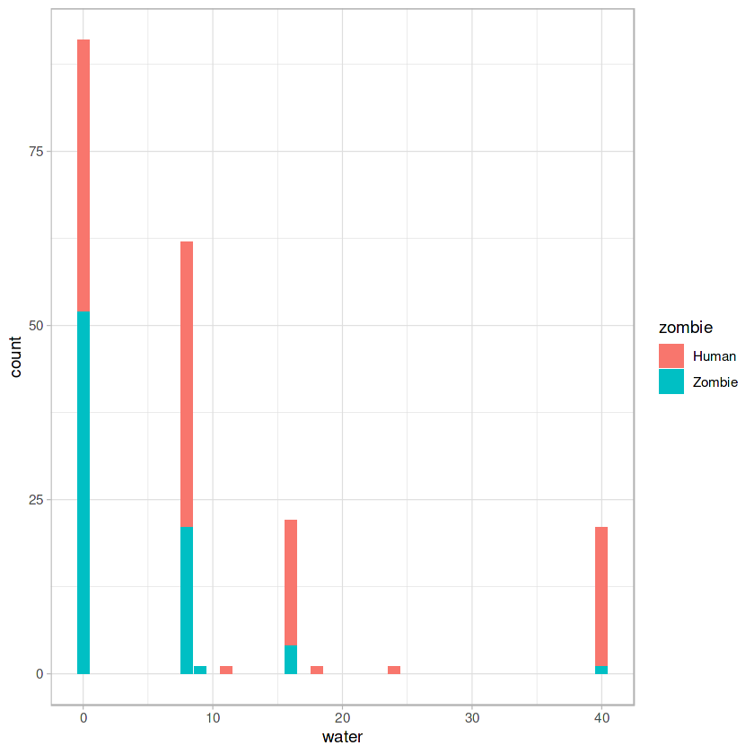

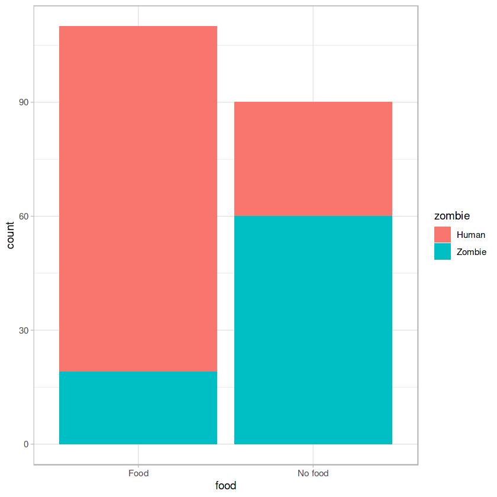

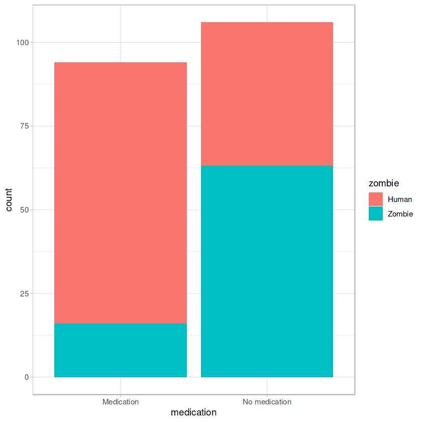

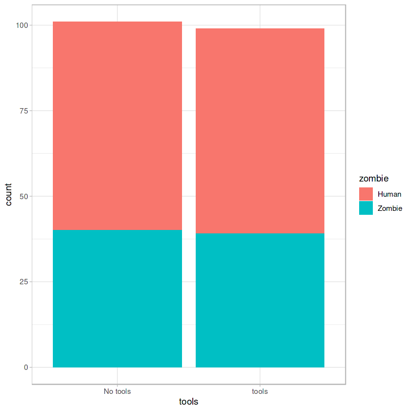

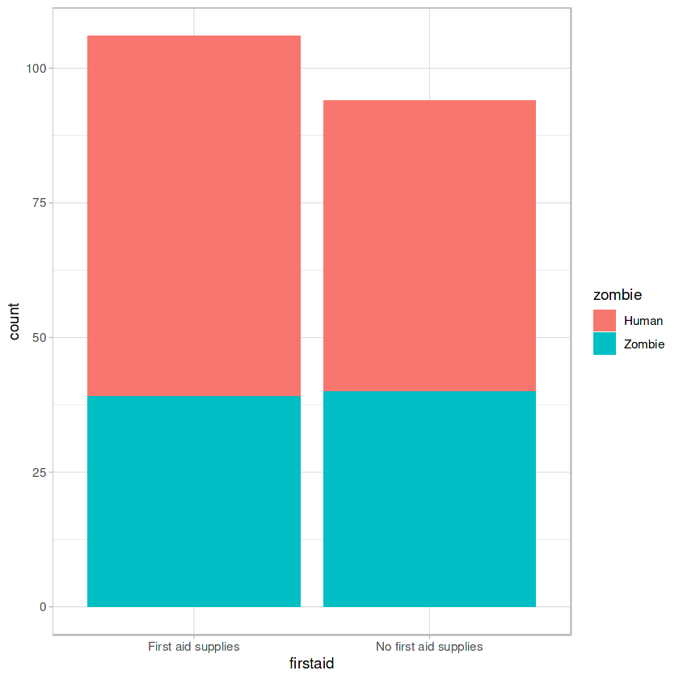

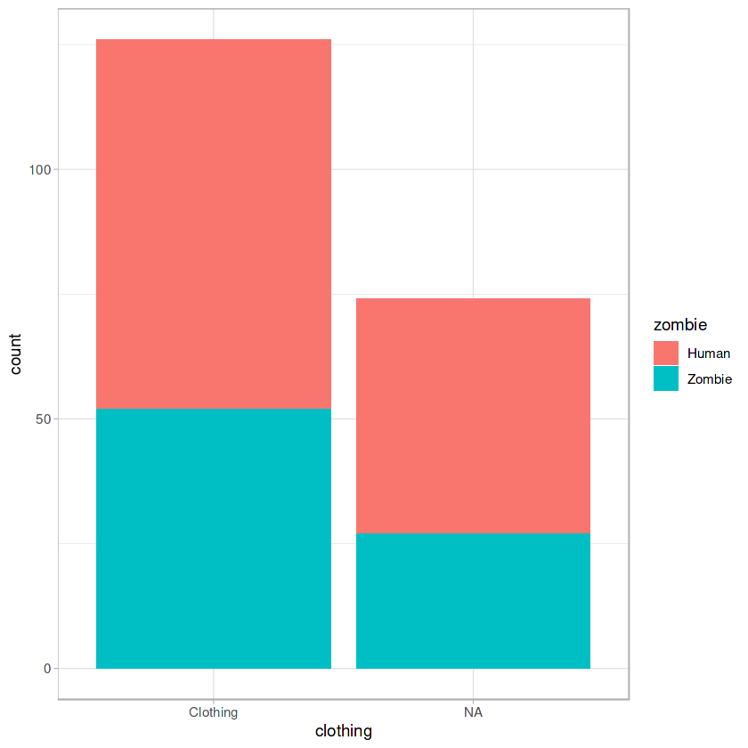

[1 more figures not shown]

```r
map(colnames(zombie_data),zombie_bar)
```

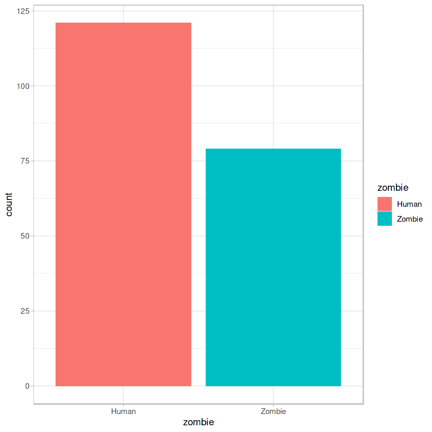

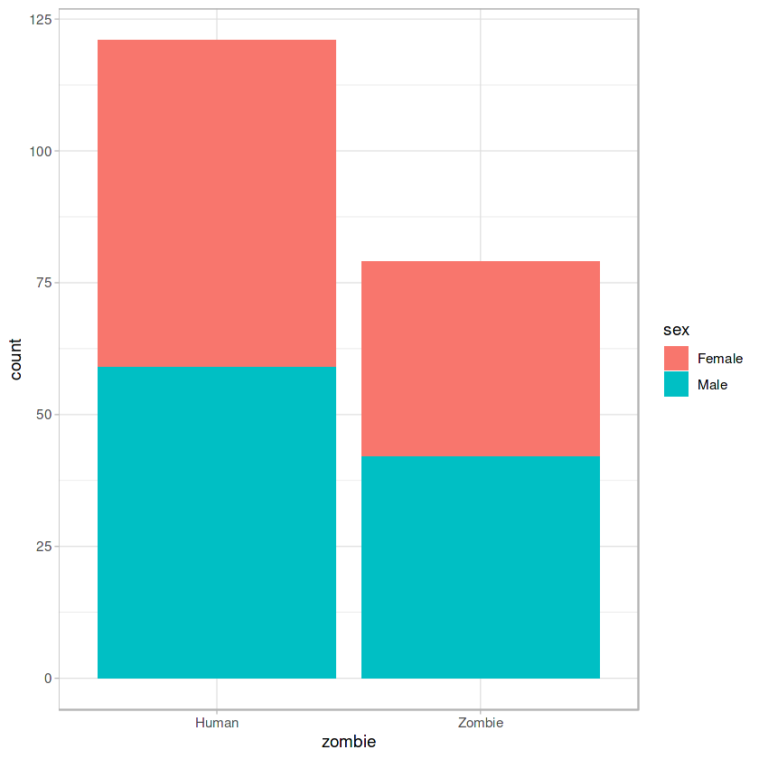

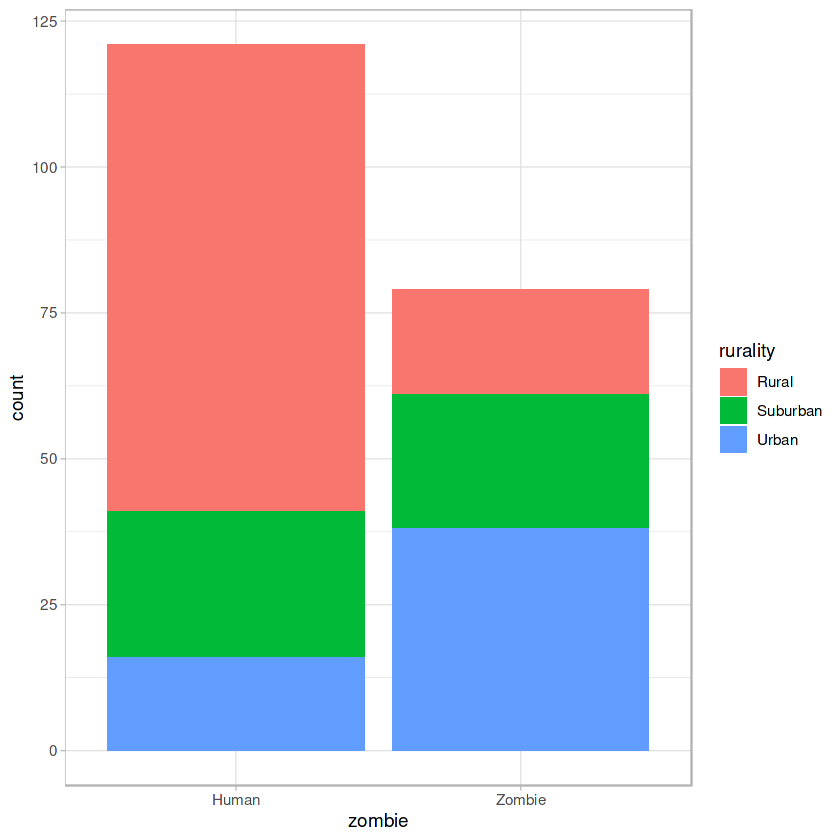

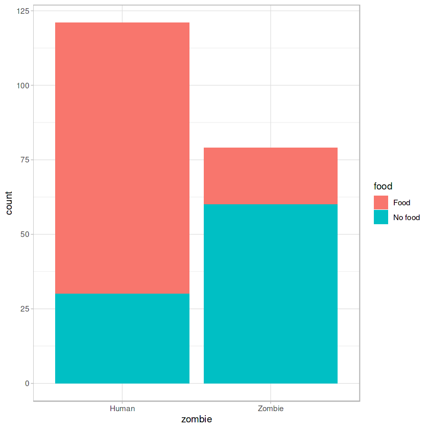

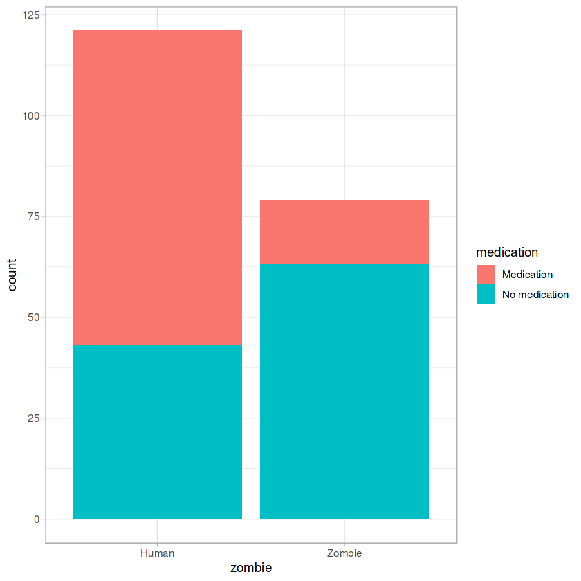

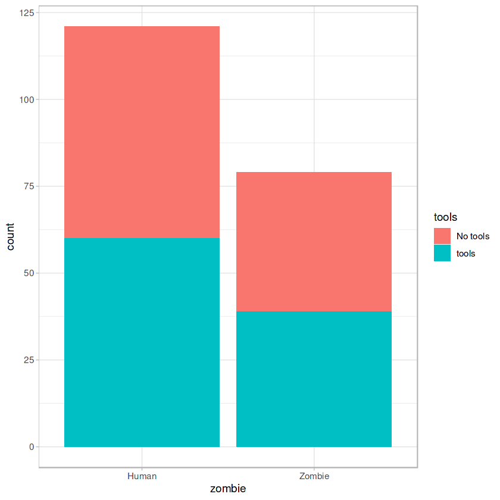

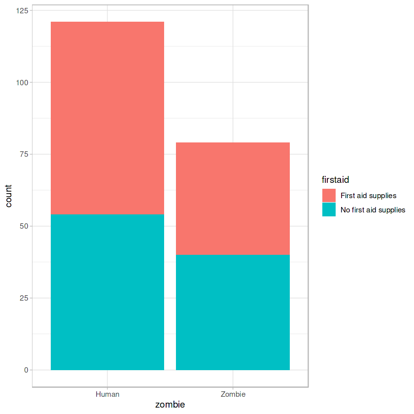

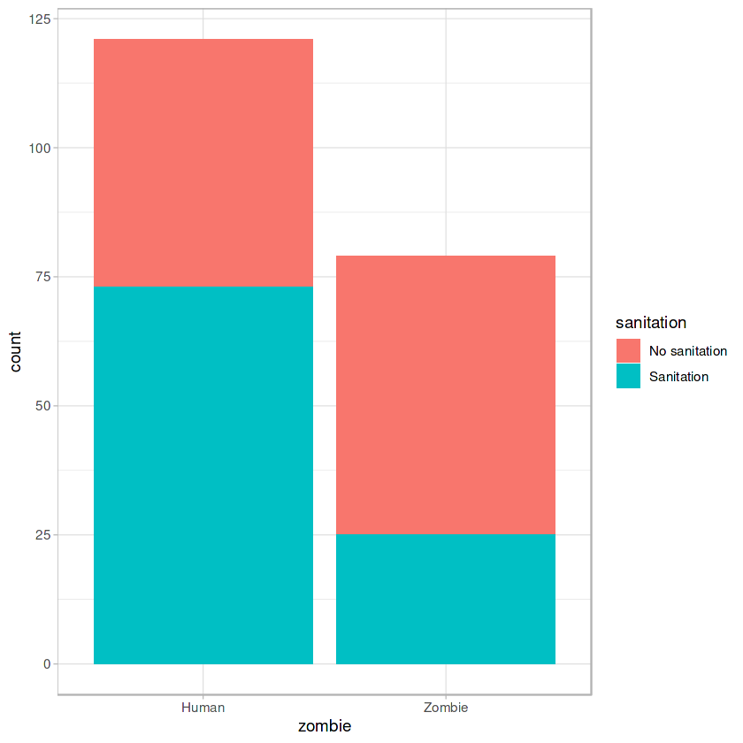

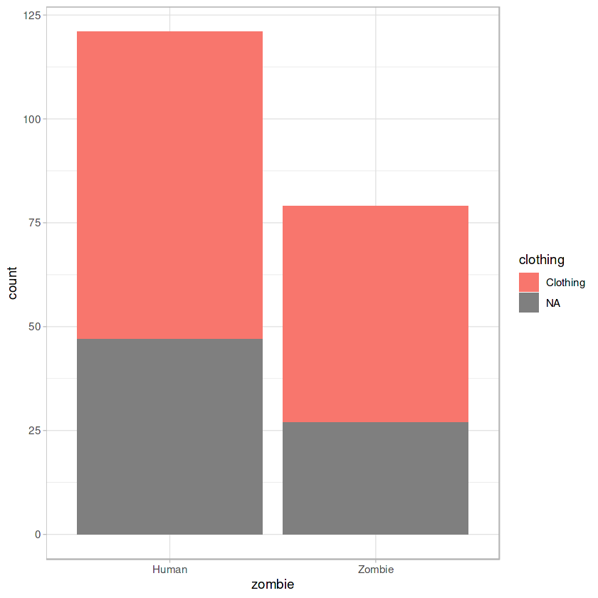

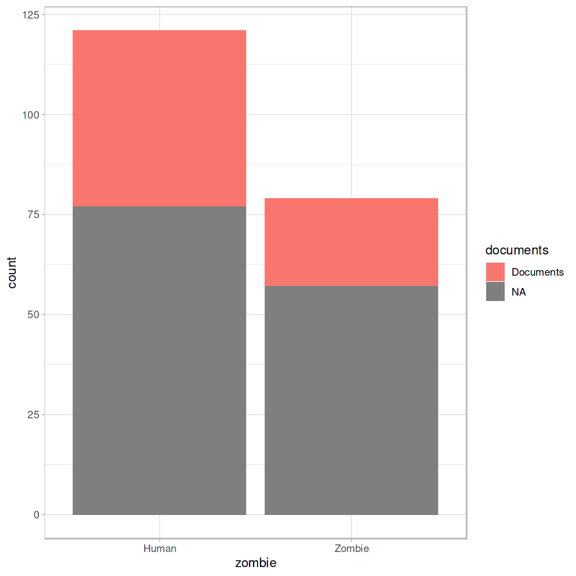

```r
map(colnames(zombie_data),zombie_bar2)
```

```r
lm(as.factor(zombie) ~ as.factor(sanitation), data=zombie_data)
```

```
Call:
lm(formula = as.factor(zombie) ~ as.factor(sanitation), data = zombie_data)

Coefficients:
                    (Intercept)  as.factor(sanitation)Sanitation
                         1.5294                          -0.2743
```

```r
zombie_bar("sanitation")
```

[output not shown]

```r
zombie_data %>%
    ggplot(aes_string(x = "sanitation", fill  = "zombie")) + geom_bar()
```

[output not shown]

```r
zombie_data %>%
    ggplot(aes(x = sanitation, fill  = zombie)) + geom_bar()
```

[output not shown]

```r
library(GGally)
```

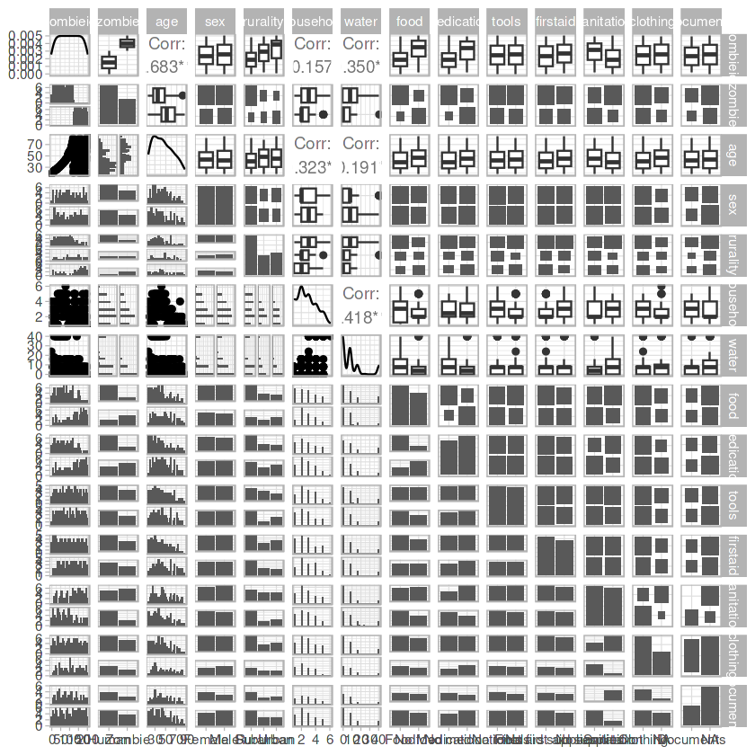

```r
ggpairs(zombie_data)
```